# CSCI E-63C Week 10 Problem Set

# Problem 4 (30 points): compare test errors of logistic regression, LDA, QDA and KNN

> Using resampling approach of your choice (e.g. cross-validation, bootstrap, etc.) obtain test error as well as sensitivity and specificity for each of these methods (logistic regression, LDA, QDA, KNN with $k=1,7,55,351$). Present results in the form of boxplots, compare test error/sensitivity/specificity across these methods and discuss their relative performance.

```r
iTries = 10
# myDf = data.frame(iTries, c("GLM", "LDA", "QDA"))

myColnames = c("#", "GLM", "LDA", "QDA")

kVals = c(1,7,55,351)
myMatrix = matrix(nrow=iTries, ncol = length(myColnames) + length(kVals))

for ( iTry in 1:iTries ) {

  # Generate training and test samples
  trainIdx <- sample(nrow(wifiData),nrow(wifiData),replace=TRUE)
  wTrain <- wifiData[trainIdx,]
  wTrainFrame <- as.data.frame(wTrain)
  wTest <- wifiData[-trainIdx,]

  # Model
  glmTry <- glm(V9~.,data=as.data.frame(wTrain),family=binomial)
  ldaTry <- lda(V9~.,data=as.data.frame(wTrain))
  colnames(wTrainFrame) = c("V1","V2","V3","V4","V5","V6","V7","V8","V9")
  colnames(wTest)       = c("V1","V2","V3","V4","V5","V6","V7","V8","V9")
  qdaTry <- qda(V9~.,data=wTrainFrame[,-8])

  # Predict
  glmTestRes     <- as.numeric(predict(glmTry,newdata=as.data.frame(wTest),type="response")>0.5)
  ldaTestRes     <- predict(ldaTry,newdata=as.data.frame(wTest))$class
  qdaTestRes     <- predict(qdaTry,newdata=as.data.frame(wTest))$class

  # Tabulate
  tblTstglm     <- table(wTest[,9],glmTestRes)
  tblTstLDA     <- table(wTest[,9],ldaTestRes)
  tblTstQDA     <- table(wTest[,9],qdaTestRes)

  # GLM, LDA, and QDA
  myRow = c( iTry,
             1 - (sum(diag(tblTstglm))     / sum(tblTstglm)),
             1 - (sum(diag(tblTstLDA))     / sum(tblTstLDA)),
             1 - (sum(diag(tblTstQDA))     / sum(tblTstQDA))
             # 1 - (sum(diag(tblTstNb))      / sum(tblTstNb))
             # 1 - (sum(diag(tblTstKknn1))   / sum(tblTstKknn1)),
             # 1 - (sum(diag(tblTstKknn7))   / sum(tblTstKknn7)),
             # 1 - (sum(diag(tblTstKknn55))  / sum(tblTstKknn55)),
             # 1 - (sum(diag(tblTstKknn351)) / sum(tblTstKknn351)),
  );

  # KNN is special
  for ( kTmp in kVals ) {
    knnTestRes <- knn(train = as.matrix(wTrain), test = as.matrix(wTest), cl = as.matrix(wTrain[,9]), k = kTmp)
    tblTstKnn <- table(wTest[,9], knnTestRes)
    myRow <- append(myRow, c( 1 - (sum(diag(tblTstKnn)) / sum(tblTstKnn) )))
  }

  myMatrix[iTry,] = myRow
}

colnames(myMatrix) <- c(myColnames, sapply(kVals, function(x) { paste("KNN k=",x); } ))
#rownames(myMatrix) <- c(1:iTries)
#rownames(myMatrix) <- c(1,2,3,4,5,6,7,8,9,10)
rownames(myMatrix) <- 1:iTries;

# library(knitr)
print("Test error rates:\n")
```

```
## [1] "Test error rates:\n"
```

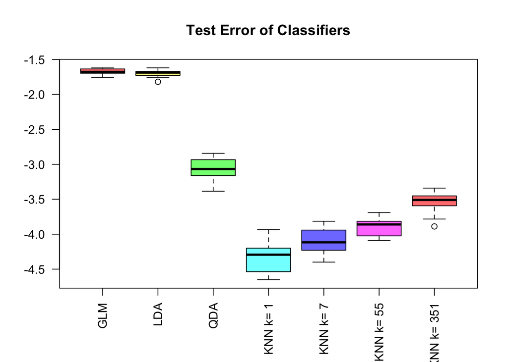

```r
boxplot(log(myMatrix[,-1]), las=2, col=rainbow(6, s=0.5), main="Test Error of Classifiers")
```

```r
myMatrix
```

```
##     #       GLM       LDA        QDA    KNN k= 1   KNN k= 7  KNN k= 55
## 1   1 0.1966988 0.1980743 0.05089409 0.013755158 0.01513067 0.01788171
## 2   2 0.1978320 0.1937669 0.03387534 0.013550136 0.01626016 0.02032520
## 3   3 0.1831956 0.1776860 0.04407713 0.017906336 0.02203857 0.02203857
## 4   4 0.1841004 0.1841004 0.03626220 0.019525802 0.01952580 0.01673640
## 5   5 0.1950887 0.1882674 0.05320600 0.009549795 0.01227831 0.01773533
## 6   6 0.1874163 0.1780455 0.04819277 0.010709505 0.01338688 0.01874163
## 7   7 0.1719834 0.1622746 0.05825243 0.013869626 0.01941748 0.02496533
## 8   8 0.1865079 0.1865079 0.05555556 0.010582011 0.01455026 0.02248677
## 9   9 0.1798365 0.1730245 0.04495913 0.014986376 0.01634877 0.02179837
## 10 10 0.1912568 0.1857923 0.04234973 0.010928962 0.01912568 0.02185792
##    KNN k= 351
## 1  0.02751032
## 2  0.03116531
## 3  0.03168044
## 4  0.03068340
## 5  0.02046385
## 6  0.02275770
## 7  0.02912621
## 8  0.03439153
## 9  0.03542234
## 10 0.02868852
```

```r
# Throws knit error
# %>%
#   kable() %>%
#   kable_styling()

# myDf <- as.data.frame(myMatrix)
# colnames(myDf) <- colnames(c("#", "GLM", "LDA", "QDA"))
# rownames(myDf) <- rownames(1:iTries)
# kable(myDf)
```

KNN outperforms them all - with $k=1$ being the optimal $k$ value.

Interesting to note the degredation in KNN’s test error rate as $k$ becomes too large.

# Extra 5 points problem: naive Bayes classifier

> Fit naive Bayes classifier (see lecture slides for examples of using `naiveBayes` function from package `e1071`) to the WiFi localization dataset with binary (location=3 or not) outcome and assess its performance on test data by resampling along with logistic regression, LDA, QDA and KNN in the Problem 4 above.

```r
# FIXME

# nb.fit=naiveBayes(Y~X,data=data.frame(Y=y1,X=x1))
# colnames(wTrainFrame) = c("V1","V2","V3","V4","V5","V6","V7","V8","V9")
# nb.fit=naiveBayes(V9~.,data=wTrainFrame[,-8])

# nbTestRes <- predict(nb.fit, newdata=wTest[,9])
# tblTstNb <- table(wTest[,9], nbTestRes)

# predict(nb.fit,newdata=wTest[,9],type="raw")
#
# plot ( x1, ifelse ( y1 == "A", 0, 1 ), col = ifelse ( y1 ==  "A",  "lightblue",  "orange" ), pch = 19 )
# # theoretical probability of B, TRUTH ( dashed ) :
# points ( xx, exp (-((xx - 2)^2) / 2 ) * 0.75 / ( exp(-((xx - 2)^2) / 2) * 0.75 + exp ( (-xx^2) / 2 ) * 0.25 ), type =  'l', col = 'red', lwd = 2, lty = 2 )
#
# # predicted prob.
# points ( xx, predict ( nb.fit, newdata = data.frame ( X = xx ), type = "raw" )[,2], col = 'red', type =  'l')
```

# Extra 10 points problem: interaction terms in logistic regression

> Add pairwise interaction terms to the logistic regression model fit in the Problem 1 above and evaluate impact of their addition on training **and** test error. You can add all pairwise interaction terms or a subset of them, in which case the rationale behind selecting such a subset has to be described in your solution.

```r
# glmFit <- glm(V9~.,data=as.data.frame(wifiData),family=binomial)

# Add all pair-wise interaction terms
glmFit <- glm(V9 ~ V1 + V1:V2 + V1:V3 + V1:V4 + V1:V5 + V1:V7 + V2:V5 + V2:V7 + V3:V4 + V3:V5 + V3:V7 + V5:V6,data=as.data.frame(wifiData),family=binomial)
summary(glmFit)
```

```
##
## Call:
## glm(formula = V9 ~ V1 + V1:V2 + V1:V3 + V1:V4 + V1:V5 + V1:V7 +
##     V2:V5 + V2:V7 + V3:V4 + V3:V5 + V3:V7 + V5:V6, family = binomial,
##     data = as.data.frame(wifiData))
##
## Deviance Residuals:
##     Min       1Q   Median       3Q      Max
## -3.8421  -0.0077  -0.0001   0.0000   2.8242
##
## Coefficients:
##               Estimate Std. Error z value Pr(>|z|)
## (Intercept) -1.555e+02  2.849e+01  -5.456 4.86e-08 ***
## V1          -6.264e+00  1.148e+00  -5.457 4.85e-08 ***
## V1:V2        4.281e-02  1.389e-02   3.081  0.00206 **
## V1:V3       -1.013e-01  1.421e-02  -7.129 1.01e-12 ***
## V1:V4       -1.066e-01  1.099e-02  -9.700  < 2e-16 ***
## V1:V5        5.909e-02  6.559e-03   9.010  < 2e-16 ***
## V1:V7       -1.831e-02  6.944e-03  -2.637  0.00837 **
## V2:V5        6.110e-03  6.413e-03   0.953  0.34072
## V2:V7       -3.131e-02  1.023e-02  -3.060  0.00222 **
## V3:V4        9.773e-02  1.009e-02   9.684  < 2e-16 ***
## V3:V5       -6.942e-02  8.874e-03  -7.823 5.15e-15 ***
## V3:V7        5.222e-02  1.192e-02   4.380 1.18e-05 ***
## V5:V6        3.720e-03  8.935e-04   4.163 3.14e-05 ***
## ---
## Signif. codes:  0 '***' 0.001 '**' 0.01 '*' 0.05 '.' 0.1 ' ' 1
##
## (Dispersion parameter for binomial family taken to be 1)
##
##     Null deviance: 2249.34  on 1999  degrees of freedom
## Residual deviance:  203.46  on 1987  degrees of freedom
## AIC: 229.46
##
## Number of Fisher Scoring iterations: 11
```

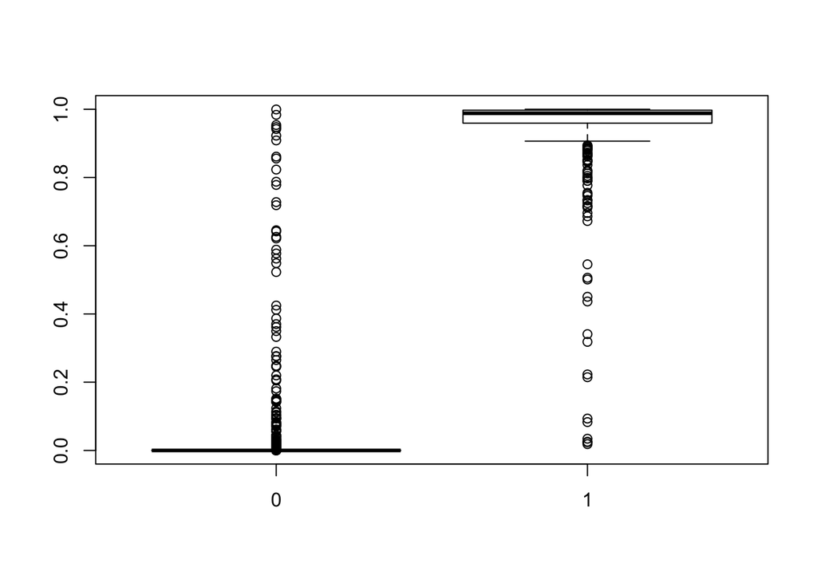

```r
boxplot(predict(glmFit,type="response")~wifiData[,9])
```

```r
quantile(predict(glmFit,type="response"))
```

```
##           0%          25%          50%          75%         100%
## 2.220446e-16 3.361351e-09 2.944107e-05 6.427956e-01 1.000000e+00
```

```r
table(wifiData[,9],c("loc 3","loc not 3")[1+(predict(glmFit)>0.0)])
```

```
##
##     loc 3 loc not 3
##   0  1477        23
##   1    12       488
```

```r
tblTmp <- table(wifiData[,9],c("loc 3","loc not 3")[1+(predict(glmFit,type="response")>0.5)])
# tblTmp
# sensitivity for predicting "loc 3":
tblTmp[2,2] / sum(tblTmp[2,])
```

```
## [1] 0.976
```

```r
# specificity for predicting "loc not 3":
tblTmp[1,1] / sum(tblTmp[1,])
```

```
## [1] 0.9846667
```

```r
rocDatTmp <- NULL

for ( qTmp in quantile(predict(glmFit,type="response"),(0:10)/10) ) {
  tblTmp <- table(wifiData[,9], factor(c("loc 3", "loc not 3")[1+(predict(glmFit, type="response")>=qTmp)], c("loc 3", "loc not 3")))
  cat(qTmp,tblTmp[2,2] / sum(tblTmp[2,]),tblTmp[1,1] / sum(tblTmp[1,]),fill=TRUE)
  rocDatTmp <- rbind(rocDatTmp,c(1-tblTmp[1,1] / sum(tblTmp[1,]),tblTmp[2,2] / sum(tblTmp[2,])))
}
```

```
## 2.220446e-16 1 0
## 2.220446e-16 1 0
## 2.1752e-10 1 0.2666667
## 4.205691e-08 1 0.4
## 1.216597e-06 1 0.5333333
## 2.944107e-05 1 0.6666667
## 0.0005307123 1 0.8
## 0.01727967 1 0.9333333
## 0.9445956 0.792 0.9973333
## 0.9931296 0.398 0.9993333
## 1 0.002 1
```

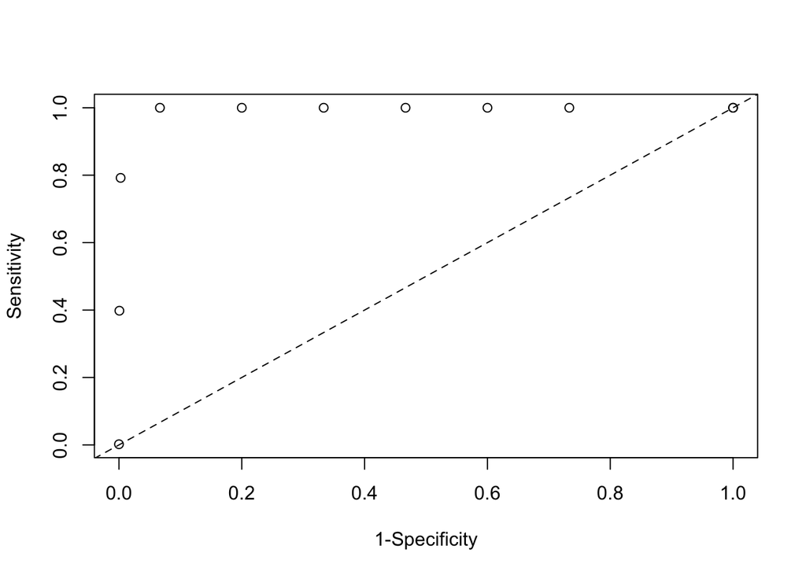

```r
plot(rocDatTmp,ylab="Sensitivity",xlab="1-Specificity")
abline(0,1,lty=2)
```

In the above model, I’ve added the most significant predictor combinations. I gathered pairs of terms by first inspecting performance of *all* term pairs ($(V1:V7)^2$).

[output not shown]

In the above output, we use the following formula (`V1 + V1:V2 + V1:V3 + V1:V4 + V1:V5 + V1:V7 + V2:V5 + V2:V7 + V3:V4 + V3:V5 + V3:V7 + V5:V6`) since these pairs are marked significant (`***`, `**`, `*`, or `,`). This gives our GLM classifier a major boost in predictive power (sensitivity and specificity increase dramatically).